# UFC Betting

Vivek Chinimilli

11/19/2020

# Introduction

We are examining historical UFC fight data in order to determine whether or not we can build a model capable of turning a profit by betting a fixed amount on each fight. We are using a stack model method containing five models: Logistic Regression, KNN, ANN, Decision Tree, Support Vector Machine. If this model turns out to be accurate, next steps include developing a constant improvement pipeline as well as an automated fightnight checker using webscraping. Success will be defined as making money using the standard Las Vegas odds in the data set with a constant $100 bid.

# Data Ingest

## Data Read-In

```r
fullData <- read.csv("ufc-master.csv")
set.seed(987654321)
```

## Fighter Extraction

```r
fighters <- c(fullData$R_fighter, fullData$B_fighter)
fighters <- fighters %>% unique()
```

## Cleaning

```r
# ALL DIFS ARE Red - BLUE
# Useless columns
fullData$R_fighter <- NULL
fullData$B_fighter <- NULL
fullData$constant_1 <- NULL
fullData$date <- NULL
fullData$location <- NULL
fullData$country <- NULL
# Factorization of Strings
fullData$weight_class <- as.factor(fullData$weight_class)
fullData$gender <- as.factor(fullData$gender)
fullData$B_Stance <- as.factor(fullData$B_Stance)
fullData$R_Stance <- as.factor(fullData$R_Stance)
fullData$empty_arena <- as.factor(fullData$empty_arena)
fullData$better_rank <- as.factor(fullData$better_rank)
fullData$title_bout <- as.factor(fullData$title_bout)
# Rank Details
fullData$R_Women.s.Bantamweight_rank <- NULL
fullData$R_Women.s.Featherweight_rank <- NULL
fullData$R_Women.s.Flyweight_rank <- NULL
fullData$R_Women.s.Strawweight_rank <- NULL
fullData$B_Women.s.Bantamweight_rank <- NULL
fullData$B_Women.s.Featherweight_rank <- NULL
fullData$B_Women.s.Flyweight_rank <- NULL
fullData$B_match_weightclass_rank <- NULL
fullData$R_match_weightclass_rank <- NULL
fullData$R_heavyweight_rank <- NULL
fullData$R_Light.Heavyweight_rank <- NULL
fullData$R_Middleweight_rank <- NULL
fullData$R_Welterweight_rank <- NULL
fullData$R_Lightweight_rank <- NULL
fullData$R_Featherweight_rank <- NULL
fullData$R_Bantamweight_rank <- NULL
fullData$R_Flyweight_rank <- NULL
fullData$R_Pound.for.Pound_rank <- NULL
fullData$B_Women.s.Strawweight_rank <- NULL
fullData$B_Heavyweight_rank <- NULL
fullData$B_Light.Heavyweight_rank <- NULL
fullData$B_Middleweight_rank <- NULL
fullData$B_Lightweight_rank <- NULL
fullData$B_Featherweight_rank <- NULL
fullData$B_Bantamweight_rank <- NULL
fullData$B_Flyweight_rank <- NULL
fullData$B_Pound.for.Pound_rank <- NULL
fullData$R_Heavyweight_rank <- NULL
fullData$B_Welterweight_rank <- NULL
# Bout specific details (Ex Post)
fullData$finish <- NULL
fullData$finish_details <- NULL
fullData$finish_round <- NULL
fullData$finish_round_time <- NULL
fullData$total_fight_time_secs <- NULL
fullData$R_kd_bout<- NULL
fullData$B_kd_bout<- NULL
fullData$R_sig_str_landed_bout<- NULL
fullData$B_sig_str_landed_bout<- NULL
fullData$R_sig_str_attempted_bout<- NULL
fullData$B_sig_str_attempted_bout<- NULL
fullData$R_sig_str_pct_bout<- NULL
fullData$B_sig_str_pct_bout<- NULL
fullData$R_tot_str_landed_bout<- NULL
fullData$B_tot_str_landed_bout<- NULL
fullData$R_tot_str_attempted_bout<- NULL
fullData$B_tot_str_attempted_bout<- NULL
fullData$R_td_landed_bout<- NULL
fullData$B_td_landed_bout<- NULL
fullData$R_td_attempted_bout<- NULL
fullData$B_td_attempted_bout<- NULL
fullData$R_td_pct_bout<- NULL
fullData$B_td_pct_bout<- NULL
fullData$R_sub_attempts_bout<- NULL
fullData$B_sub_attempts_bout<- NULL
fullData$R_pass_bout<- NULL
fullData$B_pass_bout<- NULL
fullData$R_rev_bout<- NULL
fullData$B_rev_bout<- NULL
# To make some exploratory graphics
xp <- fullData
xp$Winner <- as.factor(xp$Winner)
# Better Winner Column
fullData$RedWins <- as.factor(ifelse(fullData$Winner == "Red", 1, 0))
fullData$Winner <- NULL
fullData$ID <- seq.int(nrow(fullData))
```

Here, we remove three types of variables:

1. Character and constant features like Country, Fighter Name, Constant_1, and more.
2. We remove rank details by class as this is encoded in fighters rank detail and weight class details
3. Ex Post variables calculated after the fight. This includes finishing details and statistics of the fight like strikes landed.

In addition to dropping columns, we add a better response column, named RedWins, which is 1 if the red fighter wins and blue otherwise. Finally, we add a UID to all the fights so that we can ID the fights after predicting them.

## Normalizing and Randomizing

```r
ufc_mm <- as.data.frame(model.matrix(~.-1, fullData))
normalize <- function(x) {
  return ((x - min(x)) / (max(x) - min(x)))
}
ID_order <- ufc_mm$ID
ufc_mm_n <- as.data.frame(lapply(ufc_mm[1:(ncol(ufc_mm) - 1)], normalize))
ufc_mm_n$B_StanceSwitch. <- NULL
ufc_mm_n_no_odds <- ufc_mm_n
ufc_mm_n_no_odds$R_odds <- NULL
ufc_mm_n_no_odds$B_odds <- NULL
ufc_mm_n_no_odds$R_ev <- NULL
ufc_mm_n_no_odds$B_ev <- NULL
ufc_mm_n_knn <- ufc_mm_n[ , -91]
ufc_mm_n_knn_no_odds <- ufc_mm_n_no_odds[, -87]
```

After preparing the data frame, we then normalize all the values using min-max normalization and the create separate columns for all categorical data. This causes some columns to become corrupt and we subsequently remove them. Additionally, we remove odds and expected value from the data set as those are the odds we are trying to beat, and so it wouldn’t make sense to include those features in our analysis.

# Model Building

Because we are developing a stack model, we do not split the data in to test and train for the sub-models. Instead, we wait until we have all the predictions and then we split the data. This results in more data on which to train the stack model. However, these does lead to some overfitting concerns. With over 3000 rows, this is less of a concern however we still must be careful (notably, do not set k in k-NN to 1).

## Logical Model

```r
logit.model <- glm(RedWins1 ~., data=ufc_mm_n_no_odds, family = "binomial")
step_mod <- step(logit.model_no_odds)
```

We first build a base logical model and then use a step model to build an eventually significant model with good predictors. This step model will slowly remove columns to try and find the most significant combination of columns to predict fights.

```r
summary(step_mod)
```

```
##
## Call:
## glm(formula = RedWins1 ~ B_current_win_streak + B_avg_SIG_STR_landed +
##     B_avg_TD_landed + B_avg_TD_pct + B_win_by_Decision_Majority +
##     B_win_by_Decision_Split + B_win_by_Decision_Unanimous + B_win_by_KO.TKO +
##     B_win_by_Submission + B_win_by_TKO_Doctor_Stoppage + B_wins +
##     B_Height_cms + B_Weight_lbs + R_avg_SIG_STR_pct + R_avg_TD_landed +
##     R_losses + R_total_rounds_fought + R_win_by_Decision_Unanimous +
##     R_win_by_KO.TKO + R_win_by_Submission + R_wins + R_StanceSouthpaw +
##     R_Height_cms + R_Weight_lbs + R_age + B_age + reach_dif +
##     better_rankneither + better_rankRed, family = "binomial",
##     data = ufc_mm_n_no_odds)
##
## Deviance Residuals:
##     Min       1Q   Median       3Q      Max
## -2.2063  -1.1897   0.7592   1.0253   1.7857
##
## Coefficients:
##                               Estimate Std. Error z value        Pr(>|z|)
## (Intercept)                    3.39609    1.13206   3.000        0.002700 **
## B_current_win_streak          -1.42988    0.36939  -3.871        0.000108 ***
## B_avg_SIG_STR_landed          -0.47849    0.28446  -1.682        0.092556 .
## B_avg_TD_landed               -0.90094    0.36473  -2.470        0.013505 *
## B_avg_TD_pct                   0.29489    0.18713   1.576        0.115066
## B_win_by_Decision_Majority    -2.44285    1.03108  -2.369        0.017826 *
## B_win_by_Decision_Split       -6.82802    2.09938  -3.252        0.001144 **
## B_win_by_Decision_Unanimous  -15.91694    4.17873  -3.809        0.000140 ***
## B_win_by_KO.TKO              -30.82402    8.36500  -3.685        0.000229 ***
## B_win_by_Submission          -20.19984    5.44088  -3.713        0.000205 ***
## B_win_by_TKO_Doctor_Stoppage  -2.87636    0.91002  -3.161        0.001574 **
## B_wins                        47.45984   12.92852   3.671        0.000242 ***
## B_Height_cms                   0.86667    0.51367   1.687        0.091566 .
## B_Weight_lbs                  -1.57345    0.62884  -2.502        0.012344 *
## R_avg_SIG_STR_pct              1.00429    0.36679   2.738        0.006181 **
## R_avg_TD_landed                1.46712    0.42523   3.450        0.000560 ***
## R_losses                      -2.00252    0.61184  -3.273        0.001064 **
## R_total_rounds_fought          7.60324    5.10206   1.490        0.136164
## R_win_by_Decision_Unanimous    2.37963    0.57993   4.103 0.0000407253998 ***
## R_win_by_KO.TKO                5.78587    1.19699   4.834 0.0000013402783 ***
## R_win_by_Submission            3.30294    0.70596   4.679 0.0000028879165 ***
## R_wins                        -7.25374    1.91583  -3.786        0.000153 ***
## R_StanceSouthpaw               0.20840    0.09163   2.274        0.022944 *
## R_Height_cms                  -1.39252    0.51216  -2.719        0.006550 **
## R_Weight_lbs                   1.57991    0.63088   2.504        0.012270 *
## R_age                         -1.54079    0.28087  -5.486 0.0000000411513 ***
## B_age                          1.94256    0.28641   6.783 0.0000000000118 ***
## reach_dif                     -4.25427    1.23297  -3.450        0.000560 ***
## better_rankneither             0.38792    0.26371   1.471        0.141284
## better_rankRed                 0.46847    0.26507   1.767        0.077172 .
## ---
## Signif. codes:  0 '***' 0.001 '**' 0.01 '*' 0.05 '.' 0.1 ' ' 1
##
## (Dispersion parameter for binomial family taken to be 1)
##
##     Null deviance: 4654.9  on 3422  degrees of freedom
## Residual deviance: 4387.5  on 3393  degrees of freedom
## AIC: 4447.5
##
## Number of Fisher Scoring iterations: 6
```

```r
lm_pred <- predict(step_mod, ufc_mm_n_no_odds, type="response")
lm_pred_bin <- ifelse(lm_pred > 0.5, 1, 0)
confusionMatrix(as.factor(lm_pred_bin), as.factor(ufc_mm_n_no_odds$RedWins1), positive='1')
```

```
## Confusion Matrix and Statistics
##
##           Reference
## Prediction    0    1
##          0  556  393
##          1  878 1596
##
##                Accuracy : 0.6287
##                  95% CI : (0.6123, 0.6449)
##     No Information Rate : 0.5811
##     P-Value [Acc > NIR] : 0.000000007441
##
##                   Kappa : 0.1996
##
##  Mcnemar's Test P-Value : < 0.00000000000000022
##
##             Sensitivity : 0.8024
##             Specificity : 0.3877
##          Pos Pred Value : 0.6451
##          Neg Pred Value : 0.5859
##              Prevalence : 0.5811
##          Detection Rate : 0.4663
##    Detection Prevalence : 0.7228
##       Balanced Accuracy : 0.5951
##
##        'Positive' Class : 1
##
```

Overall, we see fairly good performance with an accuracy of approx. 63% and a kappa of about 20%. This is fairly good, but certainly leaves room for improvement. Interestingly, this model significantly over predicts the response variable (predicts a 1).

## ANN

```r
ann_model <- neuralnet(formula = RedWins1 ~ ., data = ufc_mm_n_no_odds, hidden=c(2,1), stepmax=200000, threshold = 0.03)
# obtain model results
ann_pred <- compute(ann_model, ufc_mm_n_no_odds)$net.result
ann_pred_bin <- as.factor(ifelse(ann_pred > 0.5,1,0))
#Crosstable and confusion matrix to look at results of the individual model
confusionMatrix(ann_pred_bin, as.factor(ufc_mm_n_no_odds$RedWins1), positive = "1")
```

```
## Confusion Matrix and Statistics
##
##           Reference
## Prediction    0    1
##          0  729  276
##          1  705 1713
##
##                Accuracy : 0.7134
##                  95% CI : (0.6979, 0.7285)
##     No Information Rate : 0.5811
##     P-Value [Acc > NIR] : < 0.00000000000000022
##
##                   Kappa : 0.3857
##
##  Mcnemar's Test P-Value : < 0.00000000000000022
##
##             Sensitivity : 0.8612
##             Specificity : 0.5084
##          Pos Pred Value : 0.7084
##          Neg Pred Value : 0.7254
##              Prevalence : 0.5811
##          Detection Rate : 0.5004
##    Detection Prevalence : 0.7064
##       Balanced Accuracy : 0.6848
##
##        'Positive' Class : 1
##
```

## KNN

```r
ufc_mm_n_no_odds$RedWins1 <- as.factor(ufc_mm_n_no_odds$RedWins1)
sqrt(nrow(ufc_mm_n_no_odds))
```

```
## [1] 58.50641
```

```r
knn_pred <- knn(train = ufc_mm_n_knn_no_odds, test = ufc_mm_n_knn_no_odds,
                      cl = ufc_mm_n_no_odds$RedWins1, k=37)
confusionMatrix(as.factor(knn_pred), as.factor(ufc_mm_n_no_odds$RedWins1), positive='1')
```

```
## Confusion Matrix and Statistics
##
##           Reference
## Prediction    0    1
##          0  357  215
##          1 1077 1774
##
##                Accuracy : 0.6226
##                  95% CI : (0.6061, 0.6388)
##     No Information Rate : 0.5811
##     P-Value [Acc > NIR] : 0.0000004184
##
##                   Kappa : 0.1538
##
##  Mcnemar's Test P-Value : < 0.00000000000000022
##
##             Sensitivity : 0.8919
##             Specificity : 0.2490
##          Pos Pred Value : 0.6222
##          Neg Pred Value : 0.6241
##              Prevalence : 0.5811
##          Detection Rate : 0.5183
##    Detection Prevalence : 0.8329
##       Balanced Accuracy : 0.5704
##
##        'Positive' Class : 1
##
```

## Decision Tree

```r
tree <- C5.0(formula = RedWins1 ~ ., data=ufc_mm_n_no_odds, trials = 10)
summary(tree)
```

```
##
## Call:
## C5.0.formula(formula = RedWins1 ~ ., data = ufc_mm_n_no_odds, trials = 10)
##
##
## C5.0 [Release 2.07 GPL Edition]      Tue Jan 26 20:25:37 2021
## -------------------------------
##
## Class specified by attribute `outcome'
##
## Read 3423 cases (87 attributes) from undefined.data
##
## -----  Trial 0:  -----
##
## Decision tree:
##
## age_dif > 0.5454546:
## :...empty_arena1 > 0: 1 (85/27)
## :   empty_arena1 <= 0:
## :   :...R_win_by_Decision_Split > 0: 0 (401/164)
## :       R_win_by_Decision_Split <= 0:
## :       :...longest_win_streak_dif <= 0.3461539: 1 (79/25)
## :           longest_win_streak_dif > 0.3461539: 0 (598/288)
## age_dif <= 0.5454546:
## :...R_longest_win_streak > 0.5625: 1 (29/2)
##     R_longest_win_streak <= 0.5625:
##     :...R_avg_SIG_STR_landed <= 0.01212766: 0 (30/6)
##         R_avg_SIG_STR_landed > 0.01212766:
##         :...age_dif <= 0.3939394: 1 (988/310)
##             age_dif > 0.3939394:
##             :...R_age <= 0.6538461: 1 (1183/477)
##                 R_age > 0.6538461: 0 (30/8)
##
## -----  Trial 1:  -----
##
## Decision tree:
##
## win_streak_dif <= 0.3809524: 1 (124.5/35.7)
## win_streak_dif > 0.3809524:
## :...age_dif <= 0.3939394: 1 (945.1/352.3)
```

[output cut: 92 more lines]

```
##   94.98% loss_dif
##   88.52% B_age
##   83.58% R_avg_SIG_STR_landed
##   71.14% empty_arena1
##   70.32% R_win_by_TKO_Doctor_Stoppage
##   65.24% longest_win_streak_dif
##   65.09% R_longest_win_streak
##   62.81% R_StanceSouthpaw
##   51.21% B_win_by_Decision_Unanimous
##   37.89% reach_dif
##   36.37% R_age
##   30.41% B_current_win_streak
##
##
## Time: 0.5 secs
```

```r
tree_pred <- predict(tree, ufc_mm_n_no_odds)
confusionMatrix(as.factor(tree_pred), as.factor(ufc_mm_n_no_odds$RedWins1), positive='1')
```

```
## Confusion Matrix and Statistics
##
##           Reference
## Prediction    0    1
##          0  427  246
##          1 1007 1743
##
##                Accuracy : 0.6339
##                  95% CI : (0.6176, 0.6501)
##     No Information Rate : 0.5811
##     P-Value [Acc > NIR] : 0.0000000001534
##
##                   Kappa : 0.188
##
##  Mcnemar's Test P-Value : < 0.00000000000000022
##
##             Sensitivity : 0.8763
##             Specificity : 0.2978
##          Pos Pred Value : 0.6338
##          Neg Pred Value : 0.6345
##              Prevalence : 0.5811
##          Detection Rate : 0.5092
##    Detection Prevalence : 0.8034
##       Balanced Accuracy : 0.5870
##
##        'Positive' Class : 1
##
```

With the decision tree, we see usage of a number of different features that achieves an accuracy of ~63% and a kappa of ~19%. Relatively, this is one of the worse models, similar to the KNN model. While it uses a lot of various features, the most important features are title bout, R_avg_TD_landed, win_streak_dif, and age_dif. All rows are evaluated on these four columns. Overall, most of these features make sense as they are looking at either fighter differences in wins, or body characteristics, or their ability to actually fight. Similar to KNN, this model massively over predicts 1 in the response variable. One reason this may be is that both KNN and DT essentially use the old values to predict the new ones while the other three models come up with a sort of formula to predict the outcome. Unfortunately, this is not easy to verify as many of these models are black boxes so it is hard to compare.

## SVM Model

```r
ufc_mm_n_no_odds$RedWins1 = factor(ufc_mm_n_no_odds$RedWins1)
fight_classifier_no_odds = ksvm(RedWins1 ~., data = ufc_mm_n_no_odds, kernel = "rbfdot")
svm_pred <- predict(fight_classifier_no_odds, ufc_mm_n_no_odds)
svmcm <- confusionMatrix(as.factor(svm_pred), as.factor(ufc_mm_n_no_odds$RedWins1), positive = '1')
svmcm
```

```
## Confusion Matrix and Statistics
##
##           Reference
## Prediction    0    1
##          0  596  175
##          1  838 1814
##
##                Accuracy : 0.7041
##                  95% CI : (0.6885, 0.7193)
##     No Information Rate : 0.5811
##     P-Value [Acc > NIR] : < 0.00000000000000022
##
##                   Kappa : 0.3502
##
##  Mcnemar's Test P-Value : < 0.00000000000000022
##
##             Sensitivity : 0.9120
##             Specificity : 0.4156
##          Pos Pred Value : 0.6840
##          Neg Pred Value : 0.7730
##              Prevalence : 0.5811
##          Detection Rate : 0.5299
##    Detection Prevalence : 0.7748
##       Balanced Accuracy : 0.6638
##
##        'Positive' Class : 1
##
```

# Stack Model

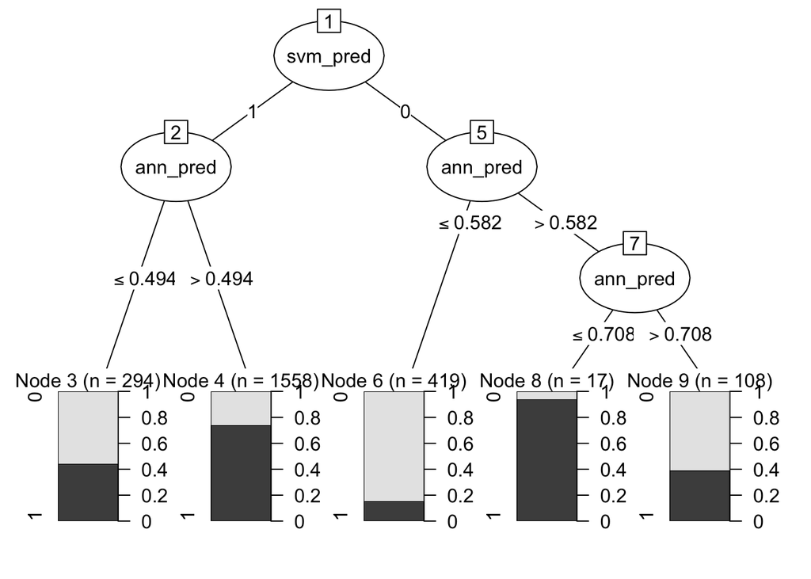

```r
results <- data.frame(ans=ufc_mm_n$RedWins1, knn_pred, ann_pred, tree_pred, svm_pred, lm_pred, ID_order)
results$ans <- as.factor(results$ans)
nums <- sample(1:nrow(results), nrow(results) * 0.7)
train <- results[nums, ]
test <- results[-nums, ]
stack <- C5.0(formula = ans ~ knn_pred + ann_pred + tree_pred + svm_pred + lm_pred, data=train, trials=5)
plot(stack)
```

```r
summary(stack)
```

```
##
## Call:
## C5.0.formula(formula = ans ~ knn_pred + ann_pred + tree_pred + svm_pred
##  + lm_pred, data = train, trials = 5)
##
##
## C5.0 [Release 2.07 GPL Edition]      Tue Jan 26 20:25:45 2021
## -------------------------------
##
## Class specified by attribute `outcome'
##
## Read 2396 cases (6 attributes) from undefined.data
##
## -----  Trial 0:  -----
##
## Decision tree:
##
## svm_pred = 1:
## :...ann_pred <= 0.4938022: 0 (294/130)
## :   ann_pred > 0.4938022: 1 (1558/408)
## svm_pred = 0:
## :...ann_pred <= 0.5822248: 0 (419/64)
##     ann_pred > 0.5822248:
##     :...ann_pred <= 0.7076318: 1 (18/1)
##         ann_pred > 0.7076318: 0 (107/41)
##
## -----  Trial 1:  -----
##
## Decision tree:
##
## svm_pred = 0: 0 (520.3/164.5)
## svm_pred = 1: 1 (1875.7/721.6)
##
## -----  Trial 2:  -----
##
## Decision tree:
##
## ann_pred > 0.4938022: 1 (1680.4/726.3)
## ann_pred <= 0.4938022:
## :...ann_pred > 0.3605482: 0 (44/1.3)
```

[output cut: 45 more lines]

```
##     (a)   (b)    <-classified as
##    ----  ----
##     585   409    (a): class 0
##     231  1171    (b): class 1
##
##
##  Attribute usage:
##
##  100.00% ann_pred
##  100.00% svm_pred
##  100.00% lm_pred
##   63.94% knn_pred
##
##
## Time: 0.0 secs
```

Overall, in the five trial decision tree, we see full usage of 3 different models: ANN, SVM and logistic regression. This means that 3 of our models are influential in prediction fight outcomes.

```r
stack_pred <- predict(stack, test)
stack_cm <- confusionMatrix(as.factor(stack_pred), as.factor(test$ans), positive='1')
stack_cm
```

```
## Confusion Matrix and Statistics
##
##           Reference
## Prediction   0   1
##          0 243  99
##          1 197 488
##
##                Accuracy : 0.7118
##                  95% CI : (0.683, 0.7393)
##     No Information Rate : 0.5716
##     P-Value [Acc > NIR] : < 0.00000000000000022
##
##                   Kappa : 0.3946
##
##  Mcnemar's Test P-Value : 0.0000000172
##
##             Sensitivity : 0.8313
##             Specificity : 0.5523
##          Pos Pred Value : 0.7124
##          Neg Pred Value : 0.7105
##              Prevalence : 0.5716
##          Detection Rate : 0.4752
##    Detection Prevalence : 0.6670
##       Balanced Accuracy : 0.6918
##
##        'Positive' Class : 1
##
```

Overall, we see an accuracy of 71.18%, which is significantly higher than our hope of better than 50%. On top of that, our kappa is 39.46%, which means we are that much better than accurate guessing, which is again very promising in our endeavor to beat the Vegas odds.

# Prediction Analysis

## Distributions

Now that we have these predictions, lets take a look at what types of fights were predicted (both properly and improperly).

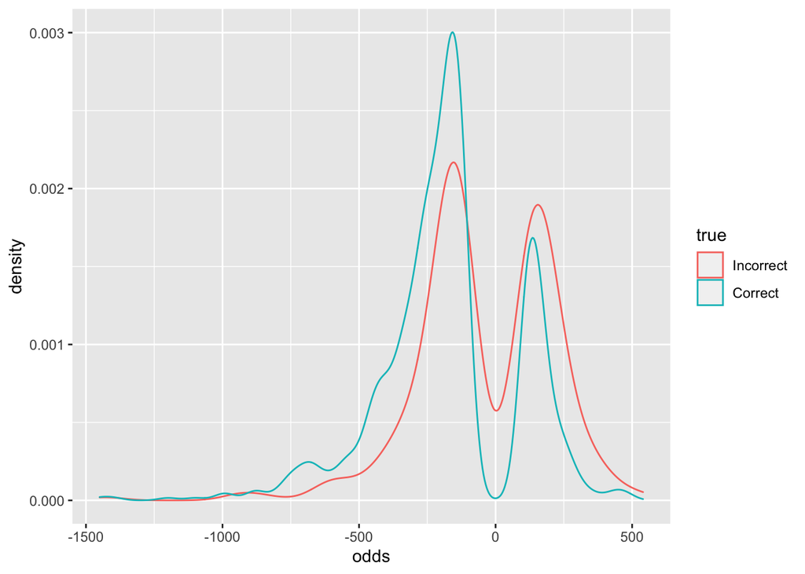

```r
red_bids <- test$ID_order[stack_pred == 1]
blue_bids <- test$ID_order[stack_pred == 0]
red_bids_data <- fullData[fullData$ID %in% red_bids, ]
blue_bids_data <- fullData[fullData$ID %in% blue_bids, ]
# For the red bids for which we are right, get outcome set to R_ev (zero otherwise, and add odds data)
temp_red <- red_bids_data %>%
  mutate(true = ifelse(RedWins == 1, 1, 0)) %>%
  mutate(outcome = ifelse(true == 1, R_ev, 0), odds = R_odds)
# For the blue bids for which we are right, get outcome set to B_ev (zero otherwise, and add odds data)
temp_blue <- blue_bids_data %>%
  mutate(true = ifelse(RedWins == 0, 1, 0)) %>%
  mutate(outcome = ifelse(true == 1, B_ev, 0), odds = B_odds)
full_bets <- rbind(temp_red, temp_blue)
full_bets$true <- as.factor(full_bets$true)
levels(full_bets$true) <- c("Incorrect", "Correct")
test <- rbind(data.frame(as.list(summary(full_bets[full_bets$true == "Correct", ]$odds))), data.frame(as.list(summary(full_bets[full_bets$true == "Incorrect", ]$odds))))
row.names(test) <- c("Correct", "Incorrect")
ggplot(data=full_bets, aes(x=odds, colour=true)) + geom_density()
```

This graph shows us exactly what we would have expected. We are more right than wrong for the odds that are negative (when the favorite wins) and we are worse for those bids where the odds are positive (where the underdog will win). There is a little bit of variation here throughout the graph, however we would expect these to even out over time. An important note here is that there are more fights with negative odds winners than positive, meaning that there are a larger proportion of fights that we get right.

|  | Min. | X1st.Qu. | Median | Mean | X3rd.Qu. | Max. |
| --- | --- | --- | --- | --- | --- | --- |
| Correct | -1450 | -300 | -175 | -177.64022 | -105 | 485 |
| Incorrect | -1430 | -170 | -110 | -43.30068 | 150 | 540 |

## Bidding Outcome

```r
# Sum up all outcomes, this is R_ev|RedWins == 1 and B_ev|RedWins == 0
sum(full_bets$outcome)
```

```
## [1] 55685.23
```

# Next Steps

## Future Improvments

Overall, this model is very promising for our ability to beat Vegas. To make this a more robust and less time intensive interaction, we should include the following improvements:

1. Implement K-fold cross validation to better develop model and train them properly
2. Implement automatic feedback and retraining as fights continue to happen
3. Create a Python program to:
   - Scrape fight information
   - Predict each fight
   - Email each UFC fight prediction
   - Provide occasional post-mortem reports on model performance
4. Create a “risk adjuster” that will only throw out predictions for fights on which it is confident beyond some value.
5. Adding some sort of temporal analysis that may drop older fights as newer fight data becomes available
6. Look into data sets with somewhat better data (there were a few columns which were improperly coded/produced NAs)
7. Develop some method to account for new fighters (maybe replace their stats with the median for their type [needs to be defined] and add a dummy variable?)

# Apendix A: Inital Exploration

Before diving in to building models, we wanted to get familiar with our data and try to understand it better. We added this here to allow the main report to deal soley with the model building.

## Response Variable Prevelance

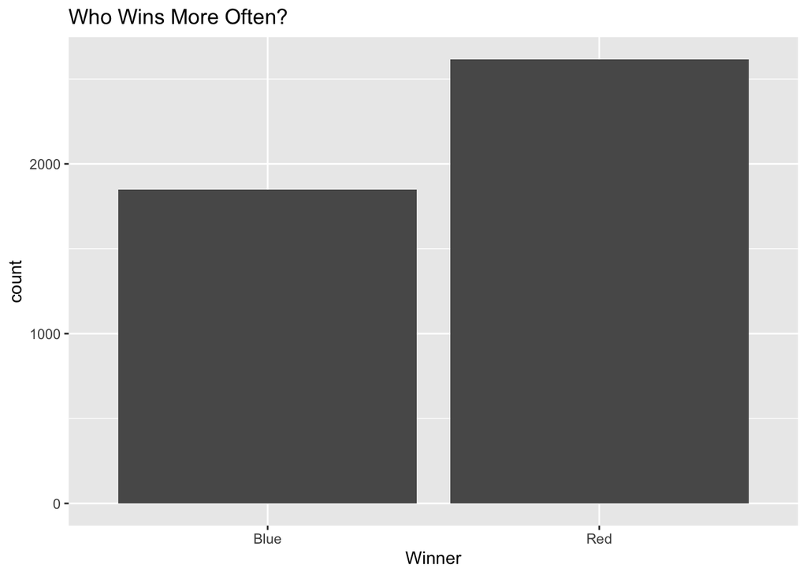

```r
ggplot(xp, aes(x=Winner)) + geom_bar() + ggtitle("Who Wins More Often?")
```

## Respionse Variabel Relations

### Age

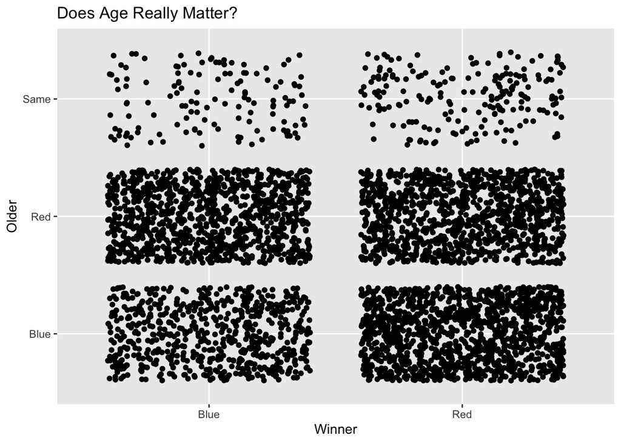

```r
xp %>%
  summarise(Winner, Older = as.factor(ifelse(R_age > B_age, "Red", ifelse(R_age < B_age, "Blue", "Same")))) %>%
ggplot(aes(x=Winner, y=Older)) + geom_jitter() + ggtitle("Does Age Really Matter?")
```

This jitter plot shows what seems to be a trend in relation to age. Essentially, the fighter who is younger looks to win more often than the fighter that is older. This finding is not too surprising and it is important to note that the Red fighter still seems to win a majority of the time (even when they are the older one), but being younger does give the blue fighter a bit of an edge.

### Body Characteristics

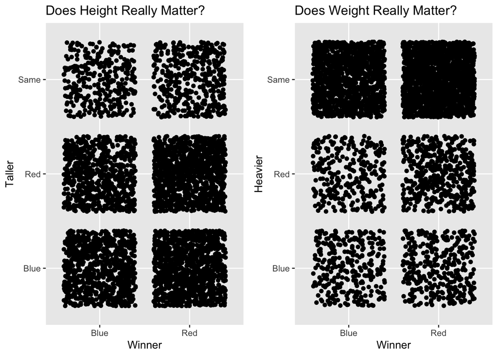

```r
height_plot <- xp %>%
  summarise(Winner, Taller = as.factor(ifelse(R_Height_cms > B_Height_cms, "Red", ifelse(R_Height_cms < B_Height_cms, "Blue", "Same")))) %>%
ggplot(aes(x=Winner, y=Taller)) + geom_jitter() + ggtitle("Does Height Really Matter?")
weight_plot <- xp %>%
  summarise(Winner, Heavier = as.factor(ifelse(R_Weight_lbs > B_Weight_lbs, "Red", ifelse(R_Weight_lbs < B_Weight_lbs, "Blue", "Same")))) %>%
ggplot(aes(x=Winner, y=Heavier)) + geom_jitter() + ggtitle("Does Weight Really Matter?")
grid.arrange(height_plot, weight_plot, ncol=2)
```

Here we see some body characteristics mapped against each other with some very subtle relations. Overall, the outcomes are fairly expected; the taller heavier fighter tends to win. This relation is somewhat less apparent than the relation to age, as Red still wins a large majority of the fights, even when they are at a disadvantage.

### Fighter History

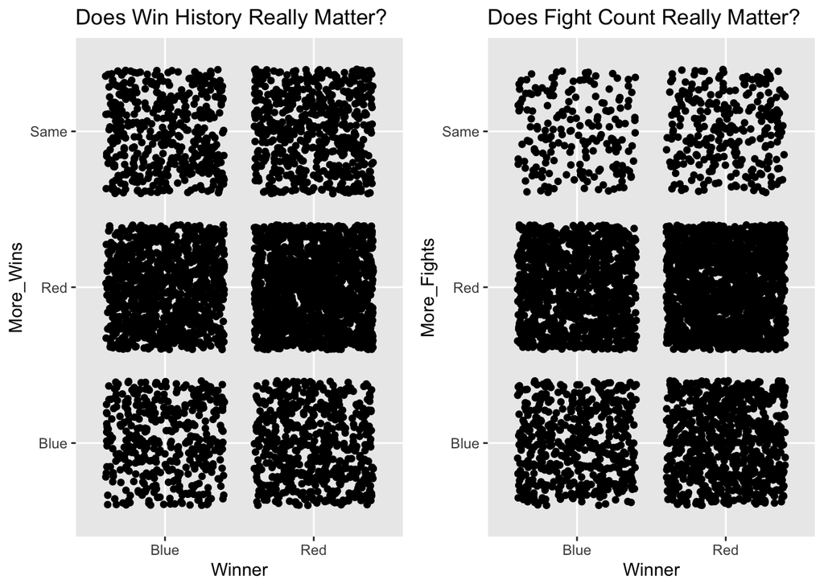

```r
wins_chart <- xp %>%
  summarise(Winner, More_Wins = as.factor(ifelse(R_wins > B_wins, "Red", ifelse(R_wins < B_wins, "Blue", "Same")))) %>%
ggplot(aes(x=Winner, y=More_Wins)) + geom_jitter() + ggtitle("Does Win History Really Matter?")
fight_chart <- xp %>%
  summarise(Winner, More_Fights = as.factor(ifelse(R_total_rounds_fought > B_total_rounds_fought, "Red", ifelse(R_total_rounds_fought < B_total_rounds_fought, "Blue", "Same")))) %>%
ggplot(aes(x=Winner, y=More_Fights)) + geom_jitter() + ggtitle("Does Fight Count Really Matter?")
grid.arrange(wins_chart, fight_chart, ncol=2)
```

Here we see a much less obvious relationship between win counts and who the winner rate will be. However, it looks like the Red fighter is often the one with more fights and more wins, which makes sense given that the “Red” designation is often given to the favorite fighter.